# Panduan PMB Seleksi Mandiri Jalur Prestasi Tahun 2022

registrasi

2022-06-25

PEDOMAN UMUM  
SELEKSI MANDIRI JALUR PRESTASI AKADEMIK DAN NON AKADEMIK  
UNIVERSITAS SULTAN AGENG TIRTAYASA  
TAHUN AKADEMIK 2022/2023

[figure not shown]

#### PENGANTAR

Seleksi Mandiri Jalur Akademik dan Non Akademik Untirta adalah seleksi penerimaan mahasiswa baru Universitas Sultan Ageng Tirtayasa yang diperuntukkan bagi siswa yang mempunyai prestasi akademik lulusan SMA/MA/SMK atau sederajat paling lama 3 (tiga) tahun terakhir, untuk memilih jurusan yang sesuai dengan kompetensi yang dimiliki. Calon mahasiswa tersebut diharapkan mampu melanjutkan prestasi yang dimiliki dengan pembinaan dari bidang kemahasiswaan Untirta sehingga dapat memperkuat Untirta dalam bidang prestasi mahasiswa.

#### RANGKAIAN SELEKSI

1. Pendaftaran (**01 – 13 Juli 2022**)
   - **Biaya Pendaftaran Rp. 350.000,-**
2. Seleksi Berkas (Portofolio) (**14 Juli 2022**)
   1. Test UTBK (**15 Juli 2022 pukul 08:00 - 10:00 WIB**)

      | Tanggal / Lokasi | Waktu | Keterangan |
      | --- | --- | --- |
      | 15 Juli 2022 Kampus Untirta Pakupatan | 08:00 - 10:00 | UTBK |
      |  | 11:00 - selesai | Wawancara dan Uji Keterampilan : Bawa Dokumen Asli Portofolio Sertifikat Prestasi |

3. Pengumuman hasil seleksi (**18 Juli 2022**)

**KETENTUAN, PERSYARATAN DAN INFORMASI KHUSUS**

**A. Ketentuan**

1. Warga Negara Indonesia
2. Lulusan SMA/MA/SMK atau sederajat paling lama 3 (tiga) tahun terakhir yang memiliki prestasi akademik maupun non akademik minimal tingkat Nasional yang dibuktikan dengan sertifikat.
3. Mendaftarkan diri sebagai peserta Seleksi Mandiri Jalur Prestasi

**B. Pesyaratan**

1. Ijazah SMA/SMK/MA/SMALB atau sederajat dan menyerahkan fotocopi ijazah
2. Memiliki NISN dan NPSN
3. Memiliki surat rekomendasi dari sekolah asal untuk melanjutkan studi ke perguruan tinggi
4. Mengikuti wawancara (calon mahasiswa) dengan pihak kampus
5. Memiliki prestasi akademik atau non akademik minimal tingkat nasional/ sebagai juara 1,2, atau 3 yang diperoleh selama masa studi di SMA/SMK/MA

**A. Informasi Khusus**

1. Pendaftar dapat memilih 2 (dua) sesuai kelompok SAINTEK dan SOSHUM dan memenuhi syarat dari masing-masing program studi.
2. Program **Studi Kedokteran** dan **Program Studi Keperawatan** tidak menerima jalur Prestasi tahun ini.
3. Untuk **Program Studi Gizi** harus berasal dari SMA/MA **IPA**.
4. Prestasi Akademik dan Non akademik merupakan kejuaraan yang dilaksanakan oleh :

   a. Pusat Prestasi Nasional

   b. Lembaga pemerintah

   c. Lembaga Swadaya Masyarakat

   d. Perguruan Tinggi

   e. Kejuaraan Internasional

   f. Lembaga lainnya yang kredibel

4. Berikut Kejuaraan yang dapat diakui sebagai jalur masuk prestasi Untirta :

**a. Kejuaraan yang dilaksanakan** oleh Pusat Prestasi Nasional Kemendikbud yaitu :

[output not shown]

**b. Kejuaraan Internasional**

[output not shown]

**c. Kejuaraan olah raga** yang dilaksanakan pada tingkat minimal nasioanal dengan cabang oleh raga **dapat memilih Prodi Ilmu Keolahragaan** :

1. Atletik
2. Renang
3. Bulutangkis
4. Tenis lapangan
5. Tenis meja
6. Sepak takraw
7. Sepak bola
8. Bola voli
9. Bola voli pantai
10. Basket
11. Futsal
12. Pencak silat
13. Taekwondo
14. Judo
15. Karate
16. Hockey
17. Pentaque
18. Kriket
19. Anggar
20. Dan Cabang olahraga lainnya

**d.** **Prestasi bidang Keagamaan** yang dilaksanakan pada tingkat minimal nasional dengan hafidz quran minimal 5 juz, dapat memilih program studi Soshum dan FKIP

**e. Kejuaraan lainnya yang diselenggarakan oleh Lembaga kredibel pada tingkat nasional**

**KUOTA MAHASISWA**

Kuota yang akan diterima melalui penenerimaan mahasiswa baru jalur mandiri prestasi khusus paling banyak 50 Orang.

**ALUR PENDAFTARAN DAN REGISTRASI JALUR PRESTASI**

[figure not shown]

#### TATA CARA PENDAFTARAN

1. Buka laman [**https://admisi.untirta.ac.id**](https://admisi.untirta.ac.id)**, Klik Daftar** pada tanda yang ditunjuk panah merah.

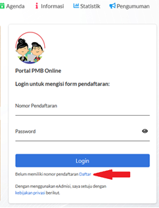

2. Masukan data yang diminta dan pilihan program studi yang diinginkan. Pastikan data diisi dengan benar (no.HP/email) karena semua data akan mejadi acuan panitia dalam berkomunikasi atu mengirim notifikasi. Satu email hanya bisa dipakai untuk mendaftar satu kali.
3. Setelah memasukan kode verifikasi dan ceklis konfirmasi kemudian klik **Daftar**.

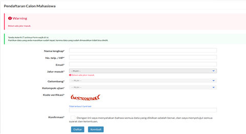

   > *Peserta dapat memilih maksimal **dua program studi**.*
4. **Cetak Bukti Pendaftaran** dan tunjukan ke petugas Teler Bank (**BNI**) untuk melakukan pembayaran sebesar **Rp350.000**, atau bisa melakukan pembayaran dengan salah satu fasilitas Bank cek [**di sini**](https://drive.google.com/file/d/1IIaFh62Irl6cK4EpdaTqcwOk3OMfmH8t/view?usp=sharing)

   contoh :

[figure not shown]

   > **Nomor Pendaftaran** = Nomor Rekening/Nomor Tagihan.

   > Pembayaran pendaftaran dilakukan untuk mengaktifkan Nomor Pendaftaran (token) dan Password. Untuk Selanjutnya bisa digunakan untuk **Login** ke [**https://admisi.untirta.ac.id**](https://admisi.untirta.ac.id/) dan melengkapi data.
5. Setelah melakukan pembayaran, buka kembali laman [**https://admisi.untirta.ac.id**](https://admisi.untirta.ac.id) kemudian pendaftar melakukan **Login,** dengan menggunakan Nomor Pendaftaran dan Password yang ada pada Bukti Pendaftaran.
6. **Lengkapi Data dengan Benar dan Jujur,** berikut dokumen yang harus dilengkapi :
   1. File Pasfoto berwarna terbaru (standar untuk ijazah) dengan wajah menghadap ke depan, ukuran 4x6 cm, **berformat *jpg**, dengan resolusi maksimum 300pxl x 450pxl, dan ukuran file maksimum 200 kb.
      1. Pakta Integritas Uang Kuliah Tunggal dan IPIN, [**Jalur Prestasi**](https://drive.google.com/file/d/1aEAVe-tMrYD8RfLY425-eeBXLLTe493Z/view?usp=sharing) (*download*, isi, *scan*, dan *upload*).

         | NO. | PROGRAM STUDI | Kelompok | IPIN (Iuran Pengembangan Institusi) |
         | --- | --- | --- | --- |
         | 1. | Hukum | SOSHUM | 15 juta |
         | 2. | Bimbingan dan Konseling | SOSHUM | 15 Juta |
         | 3. | Pendidikan Bahasa Inggris | SOSHUM | 15 Juta |
         | 4. | Pendidikan Bahasa Indonesia | SOSHUM | 15 Juta |
         | 5. | Pendidikan Biologi | SAINTEK | 20 Juta |
         | 6. | Pendidikan Fisika | SAINTEK | 20 Juta |
         | 7. | Pendidikan Guru PAUD | SOSHUM | 15 Juta |
         | 8. | Pendididikan Guru SD | SOSHUM | 15 Juta |
         | 9. | Pendidikan IPA | SAINTEK | 20 Juta |
         | 10. | Pendidikan Kimia | SAINTEK | 20 Juta |
         | 11. | Pendidikan Khusus | SOSHUM | 15 Juta |
         | 12. | Pendidikan Non Formal | SOSHUM | 15 Juta |
         | 13. | Pendidikan Matematika | SAINTEK | 20 Juta |
         | 14. | Pendidikan PPKN | SOSHUM | 15 Juta |
         | 15. | Pendidikan Sejarah | SOSHUM | 15 Juta |
         | 16. | Pendidikan Seni Pertunjukan | SOSHUM | 15 Juta |
         | 17. | Pendidikan Sosiologi | SOSHUM | 15 Juta |
         | 18. | Pendidikan Vokasi Teknik Elektro | SAINTEK | 20 Juta |
         | 19. | Pendidikan Vokasi Teknik Mesin | SIANTEK | 20 Juta |
         | 20. | Teknik Elektro | SAINTEK | 20 Juta |
         | 21. | Teknik Mesin | SAINTEK | 20 Juta |
         | 22. | Teknik Industri | SAINTEK | 20 Juta |
         | 23. | Teknik Metalurgi | SAINTEK | 20 Juta |
         | 24. | Teknik Kimia | SAINTEK | 20 Juta |
         | 25. | Teknik Sipil | SAINTEK | 20 Juta |
         | 26. | Informatika | SAINTEK | 20 Juta |
         | 27. | Agribisnis | SAINTEK | 17 Juta |
         | 28. | Agroekoteknologi | SAINTEK | 17 Juta |
         | 29. | Ilmu Perikanan | SAINTEK | 17 Juta |
         | 30. | Teknologi Pangan | SAINTEK | 17 Juta |
         | 31. | Ilmu Kelautan | SAINTEK | 17 Juta |
         | 32. | Manajemen | SOSHUM | 20 Juta |
         | 33. | Akuntansi | SOSHUM | 20 Juta |
         | 34. | Ilmu Ekonomi Pembangunan | SOSHUM | 20 Juta |
         | 35. | Ekonomi Syariah | SOSHUM | 20 Juta |
         | 36. | Administrasi Publik | SOSHUM | 15 Juta |
         | 37. | Ilmu Komunikasi | SOSHUM | 20 Juta |
         | 38. | Ilmu Pemerintahan | SOSHUM | 15 Juta |
         | 39. | Gizi | SAINTEK | 25 Juta |
         | 40. | Ilmu Keolahragaan | SAINTEK | 15 Juta |

   2. [**Surat Pernyataan Mentaati Peraturan**](https://drive.google.com/file/d/1KicWOfHIsxk0aDctxTJ0eVCwMioxHGLW/view?usp=sharing) (*download*, isi, *scan*, dan *upload*).
   3. Ijazah / Surat Keterangan Lulus bagi lulusan tahun 2022 yang belum memperoleh Ijazah. **atau Surat Keterangan Kelas XII atau Kartu Peserta Ujian Sekolah** (scan, upload)
   4. Akta Kelahiran (*scan* dan *upload*).
   5. Kartu Keluarga (*scan* dan *upload*).
   6. Bukti pembayaran listrik bagi pelanggang *pascabayar* **atau** bukti pembelian token listrik bagi pelanggan *prabayar* (*scan* dan *upload*).
   7. SPPT Pajak Bumi dan Bangunan (PBB) maximal 2 (dua) Tahun terakhir **atau** [**Surat Pernyataan tentang Luas Tanah dan Bangunan Rumah yang ditempati bagi yang tidak punya SPPT**](https://drive.google.com/file/d/1KcB8OgHbwCVpOmQ5tBbOWvJAfmTyc6sR/view?usp=sharing) (*download*, isi, *scan*, dan *upload*).
   8. Surrat Keterangan Sehat dan Tidak Buta Warna, Surat Hasil Test Narkoba dari Rumah Sakit Pemerintah / BNN.

      **Program Studi yang mensyaratkan tidak Buta Warna :**

      | No. | Program Studi | Keterangan |
      | --- | --- | --- |
      | 1. | Pendidikan Biologi | Tidak Boleh Buta Warna |
      | 2. | Pendidikan Guru Sekolah Dasar | Tidak Boleh Buta Warna |
      | 3. | Pendidikan Guru Pendidikan Anak Usia Dini | Tidak Boleh Buta Warna |
      | 4. | Pendidikan Fisika | Tidak Boleh Buta Warna |
      | 5. | Pendidikan IPA | Tidak Boleh Buta Warna |
      | 6. | Pendidikan Kimia | Tidak Boleh Buta Warna |
      | 7. | Pendidikan Vokasional Teknik Mesin | Tidak Boleh Buta Warna |
      | 8. | Pendidikan Vokasional Teknik Elektro | Tidak Boleh Buta Warna |
      | 9. | Bimbingan dan Konseling | Tidak Boleh Buta Warna |
      | 10. | Pendidikan Pancasila dan Kewarganegaraan | Tidak Boleh Buta Warna |
      | 11. | Pendidikan Sejarah | Tidak Boleh Buta Warna |
      | 12. | Pendidikan Seni Pertunjukan | Tidak Boleh Buta Warna |
      | 13. | Teknik Mesin | Tidak Boleh Buta Warna |
      | 14. | Teknik Elektro | Tidak Boleh Buta Warna |
      | 15. | Teknik Industri | Buta Warna Sebagian / Partial masih boleh |
      | 16. | Teknik Metalurgi | Tidak Boleh Buta Warna |
      | 17. | Teknik Kimia | Tidak Boleh Buta Warna |
      | 18. | Teknik Sipil | Tidak Boleh Buta Warna |
      | 19. | Informatika | Tidak Boleh Buta Warna |
      | 20. | Gizi | Tidak Boleh Buta Warna |
      | 21. | Ilmu Keolahragaan | Tidak Boleh Buta Warna |

   9. Bukti Penghasilan Ayah dan Penghasilan Ibu dengan ketentuan sebagai berikut (*scan* dan *upload*):
      - **PNS**/**TNI**/**BUMN**/**Karyawan Swasta** : Slip Gaji / Bukti Penghasilan maksimal 2 (dua) bulan terakhir **tahun 2022 (terbaru)**,
      - **Wiraswasta**/**Petani**/**Pedagang**/**Buruh**/**Tidak Mempunyai Pekerjaan Tetap** : Surat Keterangan Penghasilan dari Kelurahan dengan wajib mencantumkan **(1) NAMA PEKERJAAN (2) NOMINAL PENGHASILAN/bulan** (*scan* dan *upload*),
      - **Pensiunan** : Rekening Koran atau *print out* Buku Rekening Pensiun maksimal 2 (dua) bulan terakhir **tahun 2022 (terbaru)**.

        > **Jika Ayah sudah meninggal** kolom penghasilan di isi nol. Dokumen yang di upload Surat Kematian.

        > **Jika Ibu ibu Rumah Tangga** minta surat keterangan dari RW/Kelurahan

        > *Penghasilan Ayah dan Ibu di isi dengan data sebenarnya dan **tidak boleh 0 (nol) semua**.*
   10. **Upload Sertifikat Kejuaraan** dalam bentuk **format file pdf / zip**. Beri nama file dengan Nomor Peserta **contoh 4221107.pdf**
   11. Upload Sertifikat hasil UTBK jika mempunyai.
   12. [**Surat Pernyataan Kebenaran / Keabsahan Data**](https://drive.google.com/file/d/1MFw80ubHzl9h9FIHJNGzGmkVkNfNkEQ5/view?usp=sharing) (dowload, isi, scan dan upload)

   > **Pertanyaan / Isian yang bertanda bintang (*) wajib di isi**, sedangkan untuk pertanyaan yang tidak ada tanda bintang bisa di isi jika anda mempunyai datanya atau boleh dikosongkan.

### PENGUMUMAN KELULUSAN

1. Calon mahasiswa baru dapat melihat Pengumuman Kelulusan melalui web https://admisi.untirta.ac.id pada tab Pengumuman, atau bisa cek SK nya di web https://untirta.ac.id

[figure not shown]

2. Besaran UKT dapat dilihat dengan cara lgin kembali menggunakan nomor pendaftaran dan password saat pendaftaran, sesuai jadwal pembayaran.
3. EMPAT (4) CARA MEMBAYAR UKT DI UNTIRTA MELALUI BANK BNI : [**https://link.untirta.ac.id/UKTuntirta**](https://link.untirta.ac.id/UKTuntirta)

### **LAIN - LAIN**

**Helpdesk** pendaftaran di Gedung Pusdainfo Lantai 1, Universitas Sultan Ageng Tirtayasa. Telpon; [**0817738817**](https://wa.me/62817738817); [**081911106670**](https://wa.me/6281911106670)

**Hotline Registrasi/Admisi** : [https://wa.me/**6281311734542**](https://wa.me/6281311734542)

Email: **pmb@untirta.ac.id** dan **humas@untirta.ac.id**